# BINF5527 Machine Learning in Bioinformatics Assignment Prediction of a Variant being Disease-Related

Başak ABAK - 194220001

14 January 2021

## Introduction

Individual variants were obtained by aligning short sequences belonging to a person with the reference human genome. In this assignment I used variants of a sample patient. Each variant is labeled as “P” meaning disease-related and “N” for not disease-related. Here is the question that we want to be able to answer after exploring this dataset;  
-Prediction: given new variant, how accurate can the model predict their classes (Classification (P or N))?

## Libraries

```
library(caret)
library(DT)
library(dplyr)
library(ggplot2)
library(stats)
```

## Loading the Files

```r
myData <- read.delim("RawData.txt",sep = "\t",header = T,stringsAsFactors = F,check.names = F)
hpo <- read.delim("hpo.table",sep = "\t",header = T,stringsAsFactors = F,check.names = F)
desc <- read.delim("desc.table",sep = "\t",header = T,stringsAsFactors = F,check.names = F)
```

## Summarizing the Dataset

Take a look at the first couple of rows through head:

```r
DT::datatable(head(myData[,c(1:35)]),rownames = F,options = list(searching=F,paging=F,autoWidth = TRUE,
  columnDefs = list(list(width = '50px', targets = "_all")),scrollY = '250px',scrollX = TRUE))
```

```
## This version of Shiny is designed to work with 'htmlwidgets' >= 1.5.
##     Please upgrade via install.packages('htmlwidgets').
```

| GeneName | Chr | Start | End | Ref | Alt | type | VariantQuality | Quality | Depth | Depth_of_REF_ALT | Percentage_of_Heterozygosity | Genotype | Zygosity | Compound_Heterozygous | rsID | Func.refGene | AAChange.refGene | ExonicFunc.refGene | GeneDetail.refGene | Gene.knownGene | Func.knownGene | AAChange.knownGene | ExonicFunc.knownGene | GeneDetail.knownGene | impact_severity | gnomAD_exome_ALL | 1000g2015aug_all | ExAC_ALL | MEDIPOL_TOT_CNT | … |
| --- | --- | --- | --- | --- | --- | --- | --- | --- | --- | --- | --- | --- | --- | --- | --- | --- | --- | --- | --- | --- | --- | --- | --- | --- | --- | --- | --- | --- | --- | --- |
| AGL | chr1 | 100327026 | 100327026 | C | T | snp | 2332.06 | 99 | 72 | 0,71 | 1 | T/T | hom alt | No | rs2307129 | intronic | . | . | . | AGL | UTR5 | . | . | uc001dsn.1:c.-2C&gt;T | unknown | 0.1837 | 0.227236 | 0.1962 | 753 | … |
| AGL | chr1 | 100336361 | 100336361 | C | T | snp | 2926.06 | 99 | 90 | 0,84 | 1 | T/T | hom alt | No | rs2230306 | exonic | AGL:NM_000028.2:exon7:c.894C&gt;T:p.L298L,AGL:NM_000642.3:exon7:c.894C&gt;T:p.L298L,AGL:NM_000643.2:exon7:c.894C&gt;T:p.L298L,AGL:NM_000644.2:exon7:c.894C&gt;T:p.L298L,AGL:NM_000646.2:exon7:c.846C&gt;… | synonymous SNV | . | AGL | exonic | AGL:uc001dsn.1:exon5:c.843C&gt;T:p.L281L,AGL:uc001dsi.1:exon7:c.894C&gt;T:p.L298L,AGL:uc001dsj.1:exon7:c.894C&gt;T:p.L298L,AGL:uc001dsk.1:exon7:c.894C&gt;T:p.L298L,AGL:uc001dsl.1:exon7:c.894C&gt;T:p.L… | synonymous SNV | . | unknown | 0.7168 | 0.76258 | 0.7214 | 2614 | … |
| AGL | chr1 | 100340225 | 100340225 | G | A | snp | 2867.06 | 99 | 94 | 0,93 | 1 | A/A | hom alt | No | rs634880 | intronic | . | . | . | AGL | intronic | . | . | . | unknown | 0.7173 | 0.743411 | 0.7314 | 1550 | … |
| AGL | chr1 | 100343205 | 100343205 | G | A | snp | 906.64 | 99 | 90 | 43,39 | 0.475609756097561 | G/A | het | No | rs527819721 | exonic | AGL:NM_000028.2:exon12:c.1432G&gt;A:p.V478I,AGL:NM_000642.3:exon12:c.1432G&gt;A:p.V478I,AGL:NM_000643.2:exon12:c.1432G&gt;A:p.V478I,AGL:NM_000644.2:exon12:c.1432G&gt;A:p.V478I,AGL:NM_000646.2:exon12:c… | nonsynonymous SNV | . | AGL | exonic | AGL:uc001dsn.1:exon10:c.1381G&gt;A:p.V461I,AGL:uc001dsi.1:exon12:c.1432G&gt;A:p.V478I,AGL:uc001dsj.1:exon12:c.1432G&gt;A:p.V478I,AGL:uc001dsk.1:exon12:c.1432G&gt;A:p.V478I,AGL:uc001dsl.1:exon12:c.1432… | nonsynonymous SNV | . | MED | 0.0001 | 0.000199681 | 0.0001 | 2 | … |
| AGL | chr1 | 100353675 | 100353675 | G | A | snp | 2898.06 | 99 | 97 | 0,94 | 1 | A/A | hom alt | No | rs555929 | intronic | . | . | . | AGL | intronic | . | . | . | unknown | 0.6908 | 0.68111 | 0.6898 | 1466 | … |
| AGL | chr1 | 100358103 | 100358103 | C | T | snp | 3438.06 | 99 | 113 | 1,107 | 0.990740740740741 | T/T | hom alt | No | rs3753494 | exonic | AGL:NM_000028.2:exon24:c.3199C&gt;T:p.P1067S,AGL:NM_000642.3:exon24:c.3199C&gt;T:p.P1067S,AGL:NM_000643.2:exon24:c.3199C&gt;T:p.P1067S,AGL:NM_000644.2:exon24:c.3199C&gt;T:p.P1067S,AGL:NM_000646.2:exon… | nonsynonymous SNV | . | AGL | exonic | AGL:uc001dsn.1:exon22:c.3148C&gt;T:p.P1050S,AGL:uc001dsi.1:exon24:c.3199C&gt;T:p.P1067S,AGL:uc001dsj.1:exon24:c.3199C&gt;T:p.P1067S,AGL:uc001dsk.1:exon24:c.3199C&gt;T:p.P1067S,AGL:uc001dsl.1:exon24:c.… | nonsynonymous SNV | . | MED | 0.1349 | 0.110623 | 0.1361 | 664 | … |

## Data preprocessing

- Cleaning the data (remove duplicates, deal with missing values, data type conversions,subsetting)

```r
mycols <- c("GeneName","Chr","Start","End","Ref","Alt","Func.refGene","type","VariantQuality","Quality","Depth","Percentage_of_Heterozygosity",
            "Zygosity","Compound_Heterozygous","impact_severity","gnomAD_exome_ALL","1000g2015aug_all",
            "ExAC_ALL","MEDIPOL_TOT_CNT","MEDIPOL_HOMO_CNT","MEDIPOL_HETE_CNT","MEDIPOL_FREQ","CLNSIG","HGMD_classification",
            "Is_ACMG_Gene","InterVar","InterVar_automated","InterVarEvidences","Revel_pred","SIFT_pred","MutationTaster_pred","dann","CADD13_PHRED",
            "GERP++_RS","HGMD_Phenotype","OMIM_ClinicalSynopsis","OMIM_Phenotype","OMIM_Inheritance","HPO_Diseases","HPO_Phenotype")

mData <- myData[, c(mycols, setdiff(names(myData), mycols))]

mData <- mData[,c(1:which(colnames(mData)=="HPO_Phenotype"))]


hpo <- hpo %>%
  mutate(inf = "yes")


mData <- setDT(mData)[ i = hpo, In_Hpo := i.inf,
                       on = .(Chr,Start,End,Ref,Alt)]

mData <- mData %>%
  mutate(In_Hpo = ifelse(ExAC_ALL >0.01, NA, In_Hpo))
```

```r
mData <- mData %>%
  mutate(type = ifelse(type == "snp", 0, 1),
         Zygosity = ifelse(Zygosity == "hom alt", 0, 1),
         Compound_Heterozygous = ifelse(Compound_Heterozygous=="yes", 1, 0),
         impact_severity = ifelse(impact_severity == "HIGH", 1,ifelse(impact_severity == "MED",0,-1)),
         Is_ACMG_Gene=ifelse(Is_ACMG_Gene == "no", 0, 1),
         #In_CNV=ifelse(In_CNV == "no", 0, 1),
         Revel_pred = ifelse(Revel_pred == "Likely benign", 1,ifelse(Revel_pred == "Likely disease causing",0,-1)),
         SIFT_pred = ifelse(SIFT_pred == "Tolerated", 1,ifelse(SIFT_pred == "Deleterious",0,-1)),
         MutationTaster_pred = ifelse(MutationTaster_pred == "Disease_causing", 1,ifelse(MutationTaster_pred == "Disease_causing_aotomatic",2,
                              ifelse(MutationTaster_pred == "Polymorphism",3,ifelse(MutationTaster_pred == "Polymorphism_automatic",0,-1)))),
         HGMD_Phenotype=ifelse(HGMD_Phenotype == "No association", 0, 1),
         OMIM_ClinicalSynopsis=ifelse(OMIM_ClinicalSynopsis == "No association", 0, 1),
         OMIM_Phenotype=ifelse(OMIM_Phenotype == "No association", 0, 1),
         OMIM_Inheritance=ifelse(OMIM_Inheritance == "No association", 0, 1),
         HPO_Diseases=ifelse(HPO_Diseases == "No association", 0, 1),
         HPO_Phenotype=ifelse(HPO_Phenotype == "No association", 0, 1),
         In_Hpo=ifelse(is.na(In_Hpo), 0,1))

mData$CADD13_PHRED <- as.double(mData$CADD13_PHRED)
mData$dann <- as.double(mData$dann)
mData <- mData %>%
  mutate(Classification=ifelse(((tolower(InterVar_automated) %like% "pathogenic") |
                        (tolower(InterVar) %like% "pathogenic") |
                        HGMD_classification != "None" |
                        (tolower(CLNSIG) %like% "pathogenic")) & In_Hpo == 1 &
                          ExAC_ALL <= 0.01 & gnomAD_exome_ALL <= 0.01 & `1000g2015aug_all` <= 0.01,"P","N"))
mData$Classification <- as.factor(mData$Classification)

mData <- mData %>%
        rowwise() %>%
        mutate(Variant = paste0(GeneName,"-",Chr,":",Start,"-",End,"-",Ref,"-",Alt))
mData <- mData[,-c(1:7,23,24,26:28)]

mData <- mData[,c(30,29,1:28)]
```

## Data Analysis

The variable names and explanations:

```r
DT::datatable(desc,rownames = F,options = list(searching=F,paging=F,scrollY = '250px',scrollX = TRUE))
```

| Term | Term Description | Possible Values |
| --- | --- | --- |
| GeneName | Gene name associated with one variant (refGene). |  |
| Chr | Chromosome number |  |
| Start | Start position |  |
| End | End position |  |
| Ref | Reference base(s) |  |
| Alt | Alternate non-reference alleles |  |
| Variant | GeneName-Chr-Start-End-Ref-Alt |  |
| type | The type of variant | snp: 0 indel: 1 |
| VariantQuality | Quality score for the variant |  |
| Quality | Quality score for the assertion made in ALT |  |

[output cut: 31 more lines]

```r
#summary of the data
summary(mData)
```

```
##  Classification     In_Hpo              type         VariantQuality
##  N:38116        Min.   :0.000000   Min.   :0.00000   Min.   :   30.6
##  P:   23        1st Qu.:0.000000   1st Qu.:0.00000   1st Qu.:  416.0
##                 Median :0.000000   Median :0.00000   Median :  895.6
##                 Mean   :0.002884   Mean   :0.08988   Mean   : 1227.5
##                 3rd Qu.:0.000000   3rd Qu.:0.00000   3rd Qu.: 1650.3
##                 Max.   :1.000000   Max.   :1.00000   Max.   :15280.6
##
##     Quality          Depth         Percentage_of_Heterozygosity
##  Min.   : 0.00   Min.   :   1.00   Min.   :-1.0000
##  1st Qu.:99.00   1st Qu.:  34.00   1st Qu.: 0.4337
##  Median :99.00   Median :  64.00   Median : 0.5385
##  Mean   :91.22   Mean   :  74.94   Mean   : 0.6347
##  3rd Qu.:99.00   3rd Qu.: 102.00   3rd Qu.: 1.0000
##  Max.   :99.00   Max.   :1105.00   Max.   : 1.0000
##
##     Zygosity      Compound_Heterozygous impact_severity
##  Min.   :0.0000   Min.   :0             Min.   :-1.0000
##  1st Qu.:0.0000   1st Qu.:0             1st Qu.:-1.0000
##  Median :1.0000   Median :0             Median :-1.0000
##  Mean   :0.6455   Mean   :0             Mean   :-0.6237
##  3rd Qu.:1.0000   3rd Qu.:0             3rd Qu.: 0.0000
##  Max.   :1.0000   Max.   :0             Max.   : 1.0000
##
##  gnomAD_exome_ALL  1000g2015aug_all     ExAC_ALL       MEDIPOL_TOT_CNT
##  Min.   :-1.0000   Min.   :-1.0000   Min.   :-1.0000   Min.   :  -1
##  1st Qu.: 0.1680   1st Qu.: 0.1138   1st Qu.: 0.1897   1st Qu.: 552
##  Median : 0.4125   Median : 0.3786   Median : 0.4285   Median :1169
##  Mean   : 0.4032   Mean   : 0.2758   Mean   : 0.4149   Mean   :1374
##  3rd Qu.: 0.6817   3rd Qu.: 0.6767   3rd Qu.: 0.6866   3rd Qu.:2034
##  Max.   : 1.0000   Max.   : 1.0000   Max.   : 1.0000   Max.   :3682
##
##  MEDIPOL_HOMO_CNT MEDIPOL_HETE_CNT  MEDIPOL_FREQ      Is_ACMG_Gene
##  Min.   :  -1.0   Min.   :  -1.0   Min.   :-1.0000   Min.   :0.000000
##  1st Qu.:  17.0   1st Qu.: 229.0   1st Qu.: 0.1499   1st Qu.:0.000000
##  Median : 218.0   Median : 487.0   Median : 0.3175   Median :0.000000
##  Mean   : 437.8   Mean   : 498.1   Mean   : 0.3721   Mean   :0.006371
##  3rd Qu.: 707.0   3rd Qu.: 749.0   3rd Qu.: 0.5524   3rd Qu.:0.000000
##  Max.   :1841.0   Max.   :1840.0   Max.   : 1.0000   Max.   :1.000000
##
```

[output cut: 17 more lines]

```
##  Min.   :0.0000        Min.   :0.0000   Min.   :0.0000   Min.   :0.0000
##  1st Qu.:0.0000        1st Qu.:0.0000   1st Qu.:0.0000   1st Qu.:0.0000
##  Median :0.0000        Median :0.0000   Median :0.0000   Median :0.0000
##  Mean   :0.2871        Mean   :0.3059   Mean   :0.2871   Mean   :0.3039
##  3rd Qu.:1.0000        3rd Qu.:1.0000   3rd Qu.:1.0000   3rd Qu.:1.0000
##  Max.   :1.0000        Max.   :1.0000   Max.   :1.0000   Max.   :1.0000
##
##  HPO_Phenotype
##  Min.   :0.0000
##  1st Qu.:0.0000
##  Median :0.0000
##  Mean   :0.3039
##  3rd Qu.:1.0000
##  Max.   :1.0000
##
```

# Data Structuring

```r
#structure of the data
str(mData)
```

```
## Classes 'rowwise_df', 'tbl_df', 'tbl' and 'data.frame':  38139 obs. of  30 variables:
##  $ Classification              : Factor w/ 2 levels "N","P": 1 1 1 1 1 1 1 1 1 1 ...
##  $ In_Hpo                      : num  0 0 0 0 0 0 0 0 0 0 ...
##  $ type                        : num  0 0 0 0 0 0 0 1 1 1 ...
##  $ VariantQuality              : num  2332 2926 2867 907 2898 ...
##  $ Quality                     : int  99 99 99 99 99 99 99 99 99 22 ...
##  $ Depth                       : int  72 90 94 90 97 113 51 49 49 9 ...
##  $ Percentage_of_Heterozygosity: num  1 1 1 0.476 1 ...
##  $ Zygosity                    : num  0 0 0 1 0 0 0 1 1 1 ...
##  $ Compound_Heterozygous       : num  0 0 0 0 0 0 0 0 0 0 ...
##  $ impact_severity             : num  -1 -1 -1 0 -1 0 -1 -1 -1 -1 ...
##  $ gnomAD_exome_ALL            : num  0.1837 0.7168 0.7173 0.0001 0.6908 ...
##  $ 1000g2015aug_all            : num  0.2272 0.7626 0.7434 0.0002 0.6811 ...
##  $ ExAC_ALL                    : num  0.1962 0.7214 0.7314 0.0001 0.6898 ...
##  $ MEDIPOL_TOT_CNT             : int  753 2614 1550 2 1466 664 1483 108 108 319 ...
```

[output cut: 16 more lines]

```r
#head of the data
DT::datatable(head(mData),rownames = F,options = list(searching=F,paging=F,autoWidth = TRUE,
  columnDefs = list(list(width = '50px', targets = "_all",height='10px')),scrollY = '250px',scrollX = TRUE))
```

| Classification | In_Hpo | type | VariantQuality | Quality | Depth | Percentage_of_Heterozygosity | Zygosity | Compound_Heterozygous | impact_severity | gnomAD_exome_ALL | 1000g2015aug_all | ExAC_ALL | MEDIPOL_TOT_CNT | MEDIPOL_HOMO_CNT | MEDIPOL_HETE_CNT | MEDIPOL_FREQ | Is_ACMG_Gene | Revel_pred | SIFT_pred | MutationTaster_pred | dann | CADD13_PHRED | GERP++_RS | HGMD_Phenotype | OMIM_ClinicalSynopsis | OMIM_Phenotype | OMIM_Inheritance | HPO_Diseases | HPO_Phenotype |
| --- | --- | --- | --- | --- | --- | --- | --- | --- | --- | --- | --- | --- | --- | --- | --- | --- | --- | --- | --- | --- | --- | --- | --- | --- | --- | --- | --- | --- | --- |
| N | 0 | 0 | 2332.06 | 99 | 72 | 1 | 0 | 0 | -1 | 0.1837 | 0.227236 | 0.1962 | 753 | 85 | 583 | 0.20451 | 0 | -1 | -1 | -1 | 0.622 | 3.73 | . | 1 | 1 | 1 | 1 | 1 | 1 |
| N | 0 | 0 | 2926.06 | 99 | 90 | 1 | 0 | 0 | -1 | 0.7168 | 0.76258 | 0.7214 | 2614 | 926 | 762 | 0.70994 | 0 | -1 | -1 | -1 | 0.792 | 14.97 | . | 1 | 1 | 1 | 1 | 1 | 1 |
| N | 0 | 0 | 2867.06 | 99 | 94 | 1 | 0 | 0 | -1 | 0.7173 | 0.743411 | 0.7314 | 1550 | 537 | 476 | 0.42097 | 0 | -1 | -1 | -1 | 0.355 | 0.864 | . | 1 | 1 | 1 | 1 | 1 | 1 |
| N | 0 | 0 | 906.64 | 99 | 90 | 0.475609756097561 | 1 | 0 | 0 | 0.0001 | 0.000199681 | 0.0001 | 2 | 0 | 2 | 0.00054 | 0 | 1 | 0 | 1 | 0.999 | 27 | 5.970 | 1 | 1 | 1 | 1 | 1 | 1 |
| N | 0 | 0 | 2898.06 | 99 | 97 | 1 | 0 | 0 | -1 | 0.6908 | 0.68111 | 0.6898 | 1466 | 485 | 496 | 0.39815 | 0 | -1 | -1 | -1 | 0.325 | 3.459 | . | 1 | 1 | 1 | 1 | 1 | 1 |
| N | 0 | 0 | 3438.06 | 99 | 113 | 0.990740740740741 | 0 | 0 | 0 | 0.1349 | 0.110623 | 0.1361 | 664 | 61 | 542 | 0.18034 | 0 | 1 | 0 | 0 | 0.972 | 18.13 | 5.200 | 1 | 1 | 1 | 1 | 1 | 1 |

## Feature Plotting Before Training

The plot below represents the most important variable(s) in our prediction model.

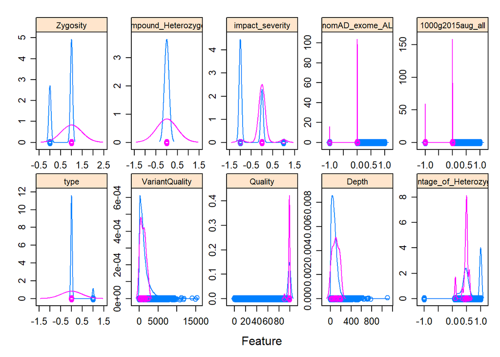

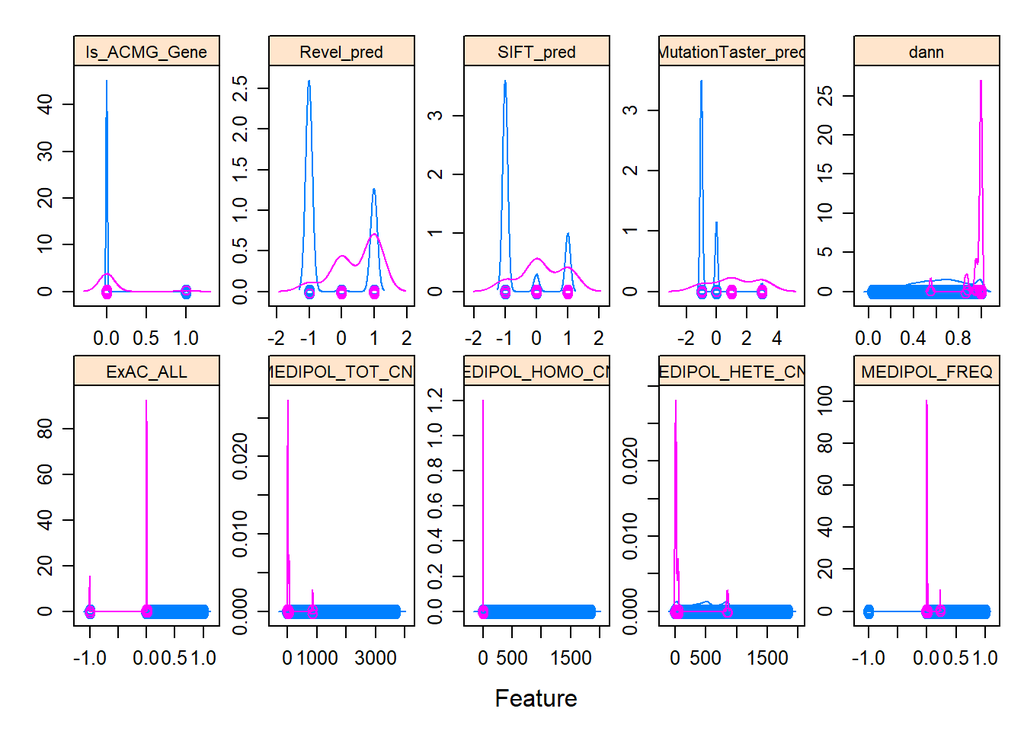

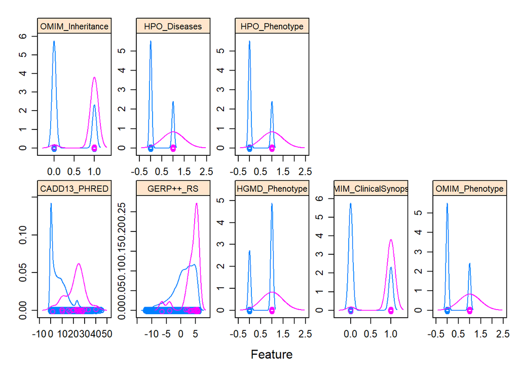

```r
featurePlot(x = mData[,3:30],
            y = as.factor(mData$Classification),
            plot = "density",
            layout = c(5, 2),
            strip=strip.custom(par.strip.text=list(cex=.7)),
            scales = list(x = list(relation="free"),
                          y = list(relation="free")))
```

## Creating Training Data Set

```r
#set the seed
set.seed(101)

#creating trainin data (%20 for training)

intrain <- createDataPartition(y = mData$Classification, p= 0.2, list = FALSE)
training <- mData[intrain,-1]
testing <- mData[-intrain,-1]
dim(training); dim(testing);
```

```
## [1] 7629   29
```

```
## [1] 30510    29
```

```r
#Create a cross validation object for 10 fold CV with 3 replicates

trctrl <- trainControl(method = "repeatedcv", number = 10,repeats = 3)
```

## Training with Support Vector Machines with Polynomial Kernel

```r
#train Radial Support Vector Machine (svmPoly) classification model

svmPolyGrid <-  expand.grid(degree= c(2:5),scale = c(1,0.1,0.01), C = c(1,10))
svmPoly <- train(as.factor(Classification) ~., data = training, method = "svmPoly",trControl=trctrl,tuneGrid = svmPolyGrid)
svmPoly
```

```
## Support Vector Machines with Polynomial Kernel
##
## 7629 samples
##   28 predictor
##    2 classes: 'N', 'P'
##
## No pre-processing
## Resampling: Cross-Validated (10 fold, repeated 3 times)
## Summary of sample sizes: 6867, 6867, 6865, 6867, 6865, 6865, ...
## Resampling results across tuning parameters:
##
##   degree  scale  C   Accuracy   Kappa
##   2       0.01    1  0.9992137  0.4120294
##   2       0.01   10  0.9992137  0.4120294
##   2       0.10    1  0.9992136  0.3997813
##   2       0.10   10  0.9992136  0.3997813
##   2       1.00    1  0.9992137  0.4120294
##   2       1.00   10  0.9992137  0.4120294
##   3       0.01    1  0.9991262  0.4012981
##   3       0.01   10  0.9991262  0.4012981
##   3       0.10    1  0.9991262  0.4012981
##   3       0.10   10  0.9991262  0.4012981
##   3       1.00    1  0.9990826  0.4012783
##   3       1.00   10  0.9990826  0.4012783
##   4       0.01    1  0.9987332  0.2646960
##   4       0.01   10  0.9987332  0.2646960
##   4       0.10    1  0.9987332  0.2646960
##   4       0.10   10  0.9987332  0.2646960
##   4       1.00    1  0.9987332  0.2646960
##   4       1.00   10  0.9987332  0.2646960
##   5       0.01    1  0.9986021  0.2495900
##   5       0.01   10  0.9986021  0.2495900
##   5       0.10    1  0.9986021  0.2495900
##   5       0.10   10  0.9986021  0.2495900
##   5       1.00    1  0.9985584  0.2495354
##   5       1.00   10  0.9985584  0.2495354
##
## Accuracy was used to select the optimal model using the largest value.
## The final values used for the model were degree = 2, scale = 0.01 and C
##  = 1.
```

## Training with Support Vector Machines with Linear Kernel

```r
#train Radial Support Vector Machine (svmLinear) classification model

svmLinearGrid <-  expand.grid(C = c(1,10))
svmLinear <- train(as.factor(Classification) ~., data = training, method = "svmLinear",trControl=trctrl,tuneGrid = svmLinearGrid)
svmLinear
```

```
## Support Vector Machines with Linear Kernel
##
## 7629 samples
##   28 predictor
##    2 classes: 'N', 'P'
##
## No pre-processing
## Resampling: Cross-Validated (10 fold, repeated 3 times)
## Summary of sample sizes: 6866, 6867, 6866, 6865, 6866, 6867, ...
## Resampling results across tuning parameters:
##
##   C   Accuracy   Kappa
##    1  0.9989517  0.03159338
##   10  0.9715552  0.05960077
##
## Accuracy was used to select the optimal model using the largest value.
## The final value used for the model was C = 1.
```

## Training with Support Vector Machines with Radial Basis Function Kernel

```r
#train Radial Support Vector Machine (svmRadial) classification model

svmRadialGrid <-  expand.grid(sigma = c(1,0.1,0.01), C = c(1,10))
svmRadial <- train(as.factor(Classification) ~., data = training, method = "svmRadial",trControl=trctrl,tuneGrid = svmRadialGrid)
svmRadial
```

```
## Support Vector Machines with Radial Basis Function Kernel
##
## 7629 samples
##   28 predictor
##    2 classes: 'N', 'P'
##
## No pre-processing
## Resampling: Cross-Validated (10 fold, repeated 3 times)
## Summary of sample sizes: 6866, 6866, 6866, 6865, 6866, 6866, ...
## Resampling results across tuning parameters:
##
##   sigma  C   Accuracy   Kappa
##   0.01    1  0.9993451  0
##   0.01   10  0.9993451  0
##   0.10    1  0.9993451  0
##   0.10   10  0.9993451  0
##   1.00    1  0.9993451  0
##   1.00   10  0.9993451  0
##
## Accuracy was used to select the optimal model using the largest value.
## The final values used for the model were sigma = 1 and C = 1.
```

## Training with K-Nearest Neighbors

```r
#train K-Nearest Neighbor (KNN) classification model

knnGrid <-  expand.grid(k = c(5, 11, 21, 25))
knn <- train(as.factor(Classification) ~., data = training, metric ="Accuracy",method = "knn",trControl=trctrl,tuneGrid = knnGrid)
knn
```

```
## k-Nearest Neighbors
##
## 7629 samples
##   28 predictor
##    2 classes: 'N', 'P'
##
## No pre-processing
## Resampling: Cross-Validated (10 fold, repeated 3 times)
## Summary of sample sizes: 6866, 6867, 6866, 6867, 6865, 6866, ...
## Resampling results across tuning parameters:
##
##   k   Accuracy   Kappa
##    5  0.9993451  0
##   11  0.9993451  0
##   21  0.9993451  0
##   25  0.9993451  0
##
## Accuracy was used to select the optimal model using the largest value.
## The final value used for the model was k = 25.
```

## Training with Random Forest

```r
# #train Random Forest (RF) classification model

rfGrid <-  expand.grid(mtry = c(1,10))
rf <- train(as.factor(Classification) ~., data = training, method = "rf",trControl=trctrl,tuneGrid = rfGrid)
rf
```

```
## Random Forest
##
## 7629 samples
##   28 predictor
##    2 classes: 'N', 'P'
##
## No pre-processing
## Resampling: Cross-Validated (10 fold, repeated 3 times)
## Summary of sample sizes: 6866, 6865, 6866, 6866, 6866, 6867, ...
## Resampling results across tuning parameters:
##
##   mtry  Accuracy   Kappa
##    1    0.9993450  0
##   10    0.9992575  0
##
## Accuracy was used to select the optimal model using the largest value.
## The final value used for the model was mtry = 1.
```

## Training with Generalized Linear Model

```r
# #train Generalized Linear Model

glm <- train(as.factor(Classification) ~., data = training, method = "glm",trControl=trctrl)
glm
```

```
## Generalized Linear Model
##
## 7629 samples
##   28 predictor
##    2 classes: 'N', 'P'
##
## No pre-processing
## Resampling: Cross-Validated (10 fold, repeated 3 times)
## Summary of sample sizes: 6866, 6867, 6866, 6867, 6865, 6866, ...
## Resampling results:
##
##   Accuracy   Kappa
##   0.9982522  0.1227175
```

## Comparision the Algorithms

From the results, it is shown that even with different parameters for each algorithm, most of the accuracy remain unchanged. This is due to the class imbalances. Altough the accuracies are high, the kappa results are mostly 0.

svmRadial(Support Vector Machines with Radial Basis Function Kernel) model with the parameters sigma = 1 and C = 1 gave the highest accuracy (0.9993451). The other algorithms also gave approximate values.

```r
results <- resamples(list(svmRadial=svmRadial, svmLinear=svmLinear, svmPoly=svmPoly,rf=rf,knn=knn,glm=glm))
summary(results)
```

```
##
## Call:
## summary.resamples(object = results)
##
## Models: svmRadial, svmLinear, svmPoly, rf, knn, glm
## Number of resamples: 30
##
## Accuracy
##                Min.   1st Qu.    Median      Mean   3rd Qu. Max. NA's
## svmRadial 0.9986894 0.9986898 0.9993455 0.9993451 1.0000000    1    0
## svmLinear 0.9973788 0.9986894 0.9986894 0.9989517 1.0000000    1    0
## svmPoly   0.9973753 0.9986894 1.0000000 0.9992137 1.0000000    1    0
## rf        0.9986894 0.9986894 0.9993455 0.9993450 1.0000000    1    0
## knn       0.9986894 0.9986898 0.9993455 0.9993451 1.0000000    1    0
## glm       0.9947575 0.9977060 0.9986885 0.9982522 0.9986894    1    0
##
## Kappa
##                   Min. 1st Qu. Median       Mean 3rd Qu.      Max. NA's
## svmRadial  0.000000000       0      0 0.00000000       0 0.0000000   15
## svmLinear -0.001312336       0      0 0.03159338       0 0.6660839    9
## svmPoly   -0.001312336       0      0 0.41202937       1 1.0000000   11
## rf         0.000000000       0      0 0.00000000       0 0.0000000   15
## knn        0.000000000       0      0 0.00000000       0 0.0000000   15
## glm       -0.001969796       0      0 0.12271751       0 1.0000000    1
```

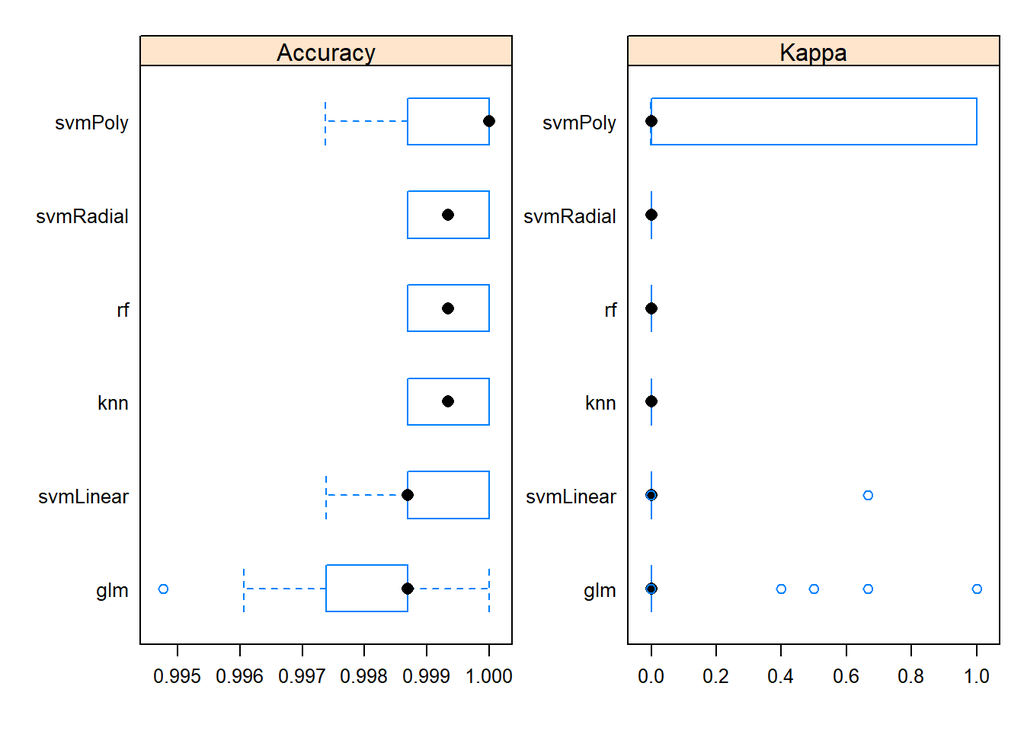

```r
scales <- list(x=list(relation="free"), y=list(relation="free"))
bwplot(results, scales=scales)
```

# Prediction Result

```r
new_variant<-c("Classification"=NA,"type"=1,"VariantQuality"=850,"Quality"=99,"Depth"=15,"Percentage_of_Heterozygosity"=0.3,"Zygosity"=1,"Compound_Heterozygous"=1,"impact_severity" =2,"gnomAD_exome_ALL"=-1,"1000g2015aug_all"=-1,"ExAC_ALL"=-1,"MEDIPOL_TOT_CNT"=1,"MEDIPOL_HOMO_CNT"=1,
        "MEDIPOL_HETE_CNT" =-1,"MEDIPOL_FREQ"=0.002,"Is_ACMG_Gene"=0,"Revel_pred"=1,"SIFT_pred"=1,
        "MutationTaster_pred"=1,"dann"=0.99,"CADD13_PHRED"=NA,"HGMD_Phenotype"=1,"OMIM_ClinicalSynopsis"=1,
        "OMIM_Phenotype"=1,"OMIM_Inheritance"=1,"HPO_Diseases"=1,"HPO_Phenotype"=1,"In_Hpo"=1)
testing<-rbind(testing, new_variant)
test_pred <- predict(svmRadial, newdata = testing)
head(test_pred)
```

```
## [1] N N N N N N
## Levels: N P
```